# 数据预处理、降维

## 一、实验目的

- 熟悉基本的数据清洗，包括缺失值处理、异常值识别。
- 掌握基本规范化方法，包括 min-max 规范化和零均值规范化。
- 主成分分析(PCA)降维的实现、可视化。

## 二、实验内容

### 1、数据清洗

- 1.1 用 pandas 读入数据“credit.csv”，查看数据集的摘要。提示：.info()。

```python
import pandas as pd
df = pd.read_csv(r"D:\编程\阿伟的笔记本\大二下\数据挖掘\作业\作业3\credit.csv")
print(df.info(verbose=True))
```

```
<class 'pandas.core.frame.DataFrame'>
RangeIndex: 6462 entries, 0 to 6461
Data columns (total 27 columns):
 #   Column                          Non-Null Count  Dtype
---  ------                          --------------  -----
 0   Cust_No                         6462 non-null   int64
 1   Target                          6462 non-null   int64
 2   Birth_Place                     6462 non-null   int64
 3   Gender                          6462 non-null   int64
 4   Age                             6462 non-null   int64
 5   Marriage_State                  4465 non-null   float64
 6   Work_Years                      6462 non-null   int64
 7   Unit_Kind                       2445 non-null   object
 8   Title                           2767 non-null   float64
 9   Year_Income                     6462 non-null   float64
```

[output cut: 20 more lines]

- 1.2 打印出缺失率最高的前 6 个特征以及对应的缺失率；

```python
alist = df.columns
bdict = dict()
for i in alist:
    a = df[i].isnull().sum()/(df[i].isnull().sum() + df[i].notnull().sum())
    bdict[i] = a
print("\n缺失率最大的 6 个属性及其缺失率:")
bdict = sorted(bdict.items(), key = lambda x : x[1], reverse = True)
j = 6
for i in bdict:
    print(i[0], '{:.2%}'.format(i[1]))
    j = j - 1
    if j == 0:
        break
```

```
缺失率最大的 6 个属性及其缺失率:
Couple_Year_Income 68.93%
Unit_Kind 62.16%
Title 57.18%
Marriage_State 30.90%
Cust_No 0.00%
Target 0.00%
```

- 1.3 对有缺失值的连续属性 Couple_Year_Income，先识别出异常值并删除，然后用不包含异常值的那些观测值的中位数来填充缺失值（参考 ppt 例子）;

```python
item = 'Couple_Year_Income'
iqr = df[item].quantile(0.75) - df[item].quantile(0.25)
q_abnormal_L = df[item] < df[item].quantile(0.25) - 1.5 * iqr
q_abnormal_U = df[item] > df[item].quantile(0.75) + 1.5 * iqr

print(item + '中有' + str(q_abnormal_L.sum() + q_abnormal_U.sum()))
item_outlier_index = df[q_abnormal_L | q_abnormal_U].index

df.drop(index = item_outlier_index, inplace = True)
print(df.shape)

df[item] = df[item].fillna(df[item].median)
```

```
Couple_Year_Income中有131
(6331, 27)
```

- 1.4 对类别属性'Marriage_State', 'Unit_Kind', 'Title'用众数填充。提示：可以调用 .value_counts()来查看离散特征的每个取值以及对应每个取值的样本数目，或者 .mode()直接得到众数。

```python
item1 = 'Marriage_State'
item2 = 'Unit_Kind'
item3 = 'Title'
df[item1] = df[item1].fillna(df[item1].mode()[0])
df[item2] = df[item2].fillna(df[item2].mode()[0])
df[item3] = df[item3].fillna(df[item3].mode()[0])
print(df.info(verbose=True))
```

```
<class 'pandas.core.frame.DataFrame'>
Int64Index: 6331 entries, 0 to 6460
Data columns (total 27 columns):
 #   Column                          Non-Null Count  Dtype
---  ------                          --------------  -----
 0   Cust_No                         6331 non-null   int64
 1   Target                          6331 non-null   int64
 2   Birth_Place                     6331 non-null   int64
 3   Gender                          6331 non-null   int64
 4   Age                             6331 non-null   int64
 5   Marriage_State                  6331 non-null   float64
 6   Work_Years                      6331 non-null   int64
 7   Unit_Kind                       6331 non-null   object
 8   Title                           6331 non-null   float64
 9   Year_Income                     6331 non-null   float64
```

[output cut: 20 more lines]

- 1.5 确认已经没有缺失值，并把数据和标签列分离分别得到 X 和 y

```python
print(df.isnull().any())
x = df.iloc[:, 2:]
y = df['Target']
print(x)
print(y)
```

```
Cust_No                           False
Target                            False
Birth_Place                       False
Gender                            False
Age                               False
Marriage_State                    False
Work_Years                        False
Unit_Kind                         False
Title                             False
Year_Income                       False
Couple_Year_Income                False
L12_Month_Pay_Amount              False
Ast_Curr_Bal                      False
Std_Cred_Limit                    False
Loan_Curr_Bal                     False
ZX_Max_Account_Number             False
ZX_Max_Link_Banks                 False
ZX_Max_Overdue_Account            False
ZX_Link_Max_Overdue_Amount        False
ZX_Total_Overdu_Months            False
ZX_Max_Overdue_Duration           False
ZX_Max_Credits                    False
ZX_Max_Credit_Banks               False
ZX_Max_Overdue_Credits            False
ZX_Credit_Max_Overdu_Amount       False
ZX_Credit_Total_Overdue_Months    False
ZX_Credit_Max_Overdue_Duration    False
dtype: bool
      Birth_Place  Gender  Age  Marriage_State  Work_Years Unit_Kind  Title  \
0          330621       1   41            20.0           0      1000    9.0
2          330621       1   55            40.0           0      1175    9.0
3          330621       1   41            20.0       68624      1175    0.0
4          330621       0   40            99.0           0      1000    9.0
6          330621       1   45            20.0           0      1000    9.0
...           ...     ...  ...             ...         ...       ...    ...
6456       342423       0   41            20.0           0      1000    9.0
6457       330621       1   40            20.0           0      1000    9.0
6458       330621       1   52            20.0           0      1000    9.0
6459       330621       0   32            10.0       68625      1000    9.0
6460       330621       1   51            99.0           0      1000    0.0
```

[output cut: 77 more lines]

```
6460                               0

[6331 rows x 25 columns]
0       0
2       0
3       0
4       0
6       0
       ..
6456    0
6457    0
6458    0
6459    0
6460    0
Name: Target, Length: 6331, dtype: int64
```

### 2、数据规范化

- 2.1 从 sklearn.datasets 导入 wine 数据集，转成 DataFrame，查看输出样本数、属性数，以及每个属性是否有缺失值。

```python
from sklearn.datasets import load_wine
#导入数据集
wine = load_wine()
df = pd.DataFrame(wine.data)
size_porperty = df.columns.size
for i in range(0, size_porperty):
    if df[i].isnull().sum() != 0:
        print("第", i, "个属性有缺失")
    else:
        print("第", i, "个属性无缺失")
```

```
第 0 个属性无缺失
第 1 个属性无缺失
第 2 个属性无缺失
第 3 个属性无缺失
第 4 个属性无缺失
第 5 个属性无缺失
第 6 个属性无缺失
第 7 个属性无缺失
第 8 个属性无缺失
第 9 个属性无缺失
第 10 个属性无缺失
第 11 个属性无缺失
第 12 个属性无缺失
```

- 2.2 统计并输出每个属性的均值、标准差。

```python
for i in range(0, size_porperty):
    print("第", i + 1, "个属性的均值是",'{:.2f}'.format(df[i].mean()),"标准差是",'{:.2}'.format(df[i].std()))
```

```
第 1 个属性的均值是 13.00 标准差是 0.81
第 2 个属性的均值是 2.34 标准差是 1.1
第 3 个属性的均值是 2.37 标准差是 0.27
第 4 个属性的均值是 19.49 标准差是 3.3
第 5 个属性的均值是 99.74 标准差是 1.4e+01
第 6 个属性的均值是 2.30 标准差是 0.63
第 7 个属性的均值是 2.03 标准差是 1.0
第 8 个属性的均值是 0.36 标准差是 0.12
第 9 个属性的均值是 1.59 标准差是 0.57
第 10 个属性的均值是 5.06 标准差是 2.3
第 11 个属性的均值是 0.96 标准差是 0.23
第 12 个属性的均值是 2.61 标准差是 0.71
第 13 个属性的均值是 746.89 标准差是 3.1e+02
```

- 2.3 对 df 所有属性进行 0-1 标准化，记为 df1。

```python
from sklearn import preprocessing
df1 = df
min_max_scaler = preprocessing.MinMaxScaler()
for i in range(0, size_porperty):
    df1[i] = min_max_scaler.fit_transform(df[i].values.reshape(-1, 1))
for i in range(0, size_porperty):
    print("第", i + 1, "个属性的均值是",'{:.2f}'.format(df1[i].mean()),"标准差是",'{:.2}'.format(df1[i].std()))
print(df1.info())
```

```
第 1 个属性的均值是 0.52 标准差是 0.21
第 2 个属性的均值是 0.32 标准差是 0.22
第 3 个属性的均值是 0.54 标准差是 0.15
第 4 个属性的均值是 0.46 标准差是 0.17
第 5 个属性的均值是 0.32 标准差是 0.16
第 6 个属性的均值是 0.45 标准差是 0.22
第 7 个属性的均值是 0.36 标准差是 0.21
第 8 个属性的均值是 0.44 标准差是 0.23
第 9 个属性的均值是 0.37 标准差是 0.18
第 10 个属性的均值是 0.32 标准差是 0.2
第 11 个属性的均值是 0.39 标准差是 0.19
第 12 个属性的均值是 0.49 标准差是 0.26
第 13 个属性的均值是 0.33 标准差是 0.22
<class 'pandas.core.frame.DataFrame'>
RangeIndex: 178 entries, 0 to 177
Data columns (total 13 columns):
 #   Column  Non-Null Count  Dtype
---  ------  --------------  -----
 0   0       178 non-null    float64
 1   1       178 non-null    float64
 2   2       178 non-null    float64
 3   3       178 non-null    float64
 4   4       178 non-null    float64
 5   5       178 non-null    float64
 6   6       178 non-null    float64
 7   7       178 non-null    float64
 8   8       178 non-null    float64
 9   9       178 non-null    float64
 10  10      178 non-null    float64
 11  11      178 non-null    float64
 12  12      178 non-null    float64
dtypes: float64(13)
memory usage: 18.2 KB
None
```

- 2.4 对 df 的每个属性进行零均值标准化（均值为 0，标准差为 1），记为 df2。

```python
df2 = df
for i in range(0, size_porperty):
    df2[i] = preprocessing.scale(df[i])
for i in range(0, size_porperty):
    print("第", i + 1, "个属性的均值是",'{:.2f}'.format(df2[i].mean()),"标准差是",'{:.2}'.format(df2[i].std()))
```

```
第 1 个属性的均值是 -0.00 标准差是 1.0
第 2 个属性的均值是 -0.00 标准差是 1.0
第 3 个属性的均值是 0.00 标准差是 1.0
第 4 个属性的均值是 -0.00 标准差是 1.0
第 5 个属性的均值是 0.00 标准差是 1.0
第 6 个属性的均值是 -0.00 标准差是 1.0
第 7 个属性的均值是 0.00 标准差是 1.0
第 8 个属性的均值是 -0.00 标准差是 1.0
第 9 个属性的均值是 0.00 标准差是 1.0
第 10 个属性的均值是 0.00 标准差是 1.0
第 11 个属性的均值是 0.00 标准差是 1.0
第 12 个属性的均值是 -0.00 标准差是 1.0
第 13 个属性的均值是 0.00 标准差是 1.0
```

- 2.5 计算并输出 df1 和 df2 每个属性的最大、最小值、均值、标准差。

```python
# df1
print("df1:")
for i in range(0, size_porperty):
    print("第", i + 1, "个属性的最大值是",'{:.2f}'.format(df1[i].max()))
    print("第", i + 1, "个属性的最小值是",'{:.2f}'.format(df1[i].min()))
    print("第", i + 1, "个属性均值是",'{:.2f}'.format(df1[i].mean()))
    print("第", i + 1, "个属性的标准差是",'{:.2f}'.format(df1[i].std()))
# df2
print("df2:")
for i in range(0, size_porperty):
    print("第", i + 1, "个属性的最大值是",'{:.2f}'.format(df2[i].max()))
    print("第", i + 1, "个属性的最小值是",'{:.2f}'.format(df2[i].min()))
    print("第", i + 1, "个属性均值是",'{:.2f}'.format(df2[i].mean()))
    print("第", i + 1, "个属性的标准差是",'{:.2f}'.format(df2[i].std()))
```

```
df1:
第 1 个属性的最大值是 2.26
第 1 个属性的最小值是 -2.43
第 1 个属性均值是 -0.00
第 1 个属性的标准差是 1.00
第 2 个属性的最大值是 3.11
第 2 个属性的最小值是 -1.43
第 2 个属性均值是 -0.00
第 2 个属性的标准差是 1.00
第 3 个属性的最大值是 3.16
第 3 个属性的最小值是 -3.68
第 3 个属性均值是 0.00
第 3 个属性的标准差是 1.00
第 4 个属性的最大值是 3.15
第 4 个属性的最小值是 -2.67
第 4 个属性均值是 -0.00
第 4 个属性的标准差是 1.00
第 5 个属性的最大值是 4.37
第 5 个属性的最小值是 -2.09
第 5 个属性均值是 0.00
第 5 个属性的标准差是 1.00
第 6 个属性的最大值是 2.54
第 6 个属性的最小值是 -2.11
第 6 个属性均值是 -0.00
第 6 个属性的标准差是 1.00
第 7 个属性的最大值是 3.06
第 7 个属性的最小值是 -1.70
第 7 个属性均值是 0.00
第 7 个属性的标准差是 1.00
第 8 个属性的最大值是 2.40
第 8 个属性的最小值是 -1.87
第 8 个属性均值是 -0.00
第 8 个属性的标准差是 1.00
第 9 个属性的最大值是 3.49
第 9 个属性的最小值是 -2.07
第 9 个属性均值是 0.00
第 9 个属性的标准差是 1.00
第 10 个属性的最大值是 3.44
第 10 个属性的最小值是 -1.63
第 10 个属性均值是 0.00
```

[output cut: 51 more lines]

```
第 10 个属性的最小值是 -1.63
第 10 个属性均值是 0.00
第 10 个属性的标准差是 1.00
第 11 个属性的最大值是 3.30
第 11 个属性的最小值是 -2.09
第 11 个属性均值是 0.00
第 11 个属性的标准差是 1.00
第 12 个属性的最大值是 1.96
第 12 个属性的最小值是 -1.90
第 12 个属性均值是 -0.00
第 12 个属性的标准差是 1.00
第 13 个属性的最大值是 2.97
第 13 个属性的最小值是 -1.49
第 13 个属性均值是 0.00
第 13 个属性的标准差是 1.00
```

- 2.6 比对上面结果并讨论 0-1 标准化和零均值标准化的作用及不同之处。

### 3、PCA 降维及可视化

说明：以下实验可调用 linalg.eig 或 linalg.svd 求特征向量，但不能直接调用其他 PCA 库3函数。

#### 任务 1：降维前后分布对比

- 3.1 对 df（原始 wine 数据）实现 PCA 降维，降成两维后得到 df_re。

```python
import numpy as np
import pandas as pd
# 计算协方差矩阵
X_mean = np.mean(df, axis=0)
X_centered = df - X_mean
cov_matrix = np.cov(X_centered.T)
# 计算特征值和特征向量
eig_vals, eig_vecs = np.linalg.eig(cov_matrix)
# 取前两个特征向量组成投影矩阵
projection_matrix = eig_vecs[:, :2]
# 对数据进行投影
X_reduced = np.dot(X_centered, projection_matrix)
# 将结果保存到DataFrame中
df_re = pd.DataFrame(X_reduced, columns=['PC1', 'PC2'])
print(df_re)
```

```
          PC1       PC2
0   -3.316751  1.443463
1   -2.209465 -0.333393
2   -2.516740  1.031151
3   -3.757066  2.756372
4   -1.008908  0.869831
..        ...       ...
173  3.370524  2.216289
174  2.601956  1.757229
175  2.677839  2.760899
176  2.387017  2.297347
177  3.208758  2.768920

[178 rows x 2 columns]
```

- 3.2 对 df2（零均值标准化后的 wine 数据）实现 PCA 降维，降成两维得到 df2_re。

```python
df2mean=df2.mean()
df2_re=df2.copy()
# 计算协方差矩阵
X_mean = np.mean(df2, axis=0)
X_centered = df2 - X_mean
cov_matrix = np.cov(X_centered.T)
# 计算特征值和特征向量
eig_vals, eig_vecs = np.linalg.eig(cov_matrix)
# 取前两个特征向量组成投影矩阵
projection_matrix = eig_vecs[:, :2]
# 对数据进行投影
X_reduced = np.dot(X_centered, projection_matrix)
# 将结果保存到DataFrame中
df2_re = pd.DataFrame(X_reduced, columns=['PC1', 'PC2'])
print(df2_re)
```

```
          PC1       PC2
0   -3.316751  1.443463
1   -2.209465 -0.333393
2   -2.516740  1.031151
3   -3.757066  2.756372
4   -1.008908  0.869831
..        ...       ...
173  3.370524  2.216289
174  2.601956  1.757229
175  2.677839  2.760899
176  2.387017  2.297347
177  3.208758  2.768920

[178 rows x 2 columns]
```

- 3.3 按照实验 2 的方式将 df_re 和 df2_re 分别绘制成散点图。

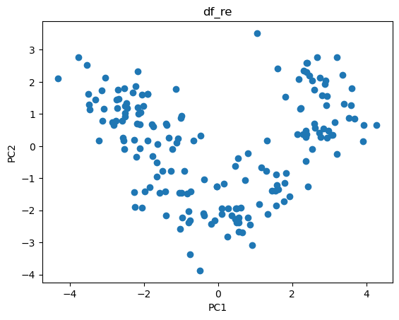

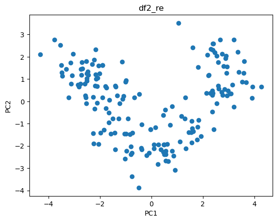

```python
import matplotlib.pyplot as plt
# 绘制 df_re 的散点图
plt.scatter(df_re['PC1'], df_re['PC2'])
plt.title('df_re')
plt.xlabel('PC1')
plt.ylabel('PC2')
plt.show()
# 绘制 df2_re 的散点图
plt.scatter(df2_re['PC1'], df2_re['PC2'])
plt.title('df2_re')
plt.xlabel('PC1')
plt.ylabel('PC2')
plt.show()
```

- 3.4 观察 df_re 和 df2_re 的散点图，分析并讨论结果。

#### 任务 2：重构误差与维度的关系

- 3.5 将 df2 降成 k 维，k 分别取 2,4,6,8,10。

```python
import numpy as np
# 对 df2 进行零均值标准化处理
df2_scaled = (df2 - np.mean(df2, axis=0)) / np.std(df2, axis=0)
# 使用 SVD 求解特征向量
u, s, vh = np.linalg.svd(df2_scaled, full_matrices=False)
# 选择前 k 个重要的特征向量
for k in [2, 4, 6, 8, 10]:
    W = u[:, :k]
    # 将 df2 降成 k 维
    df2_reduced = np.dot(W.T, df2_scaled).T
    print('k = {}, df2_reduced.shape = {}'.format(k, df2_reduced.shape))
```

```
k = 2, df2_reduced.shape = (13, 2)
k = 4, df2_reduced.shape = (13, 4)
k = 6, df2_reduced.shape = (13, 6)
k = 8, df2_reduced.shape = (13, 8)
k = 10, df2_reduced.shape = (13, 10)
```

- 3.6 以重构误差为纵坐标，k 为横坐标画折线图。

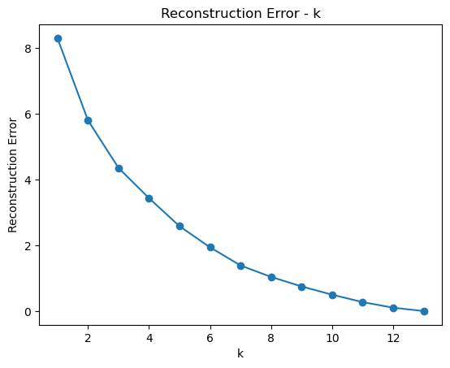

```python
import matplotlib.pyplot as plt
# 对 df2 进行零均值标准化处理
df2_scaled = (df2 - np.mean(df2, axis=0)) / np.std(df2, axis=0)
# 计算重构误差
errors = []
for k in range(1, 14):
    # 使用 SVD 求解特征向量
    u, s, vh = np.linalg.svd(df2_scaled, full_matrices=False)
    W = u[:, :k]
    # 将 df2 降成 k 维
    df2_reduced = np.dot(W.T, df2_scaled).T
    # 计算重构误差
    error = np.mean(np.sum((df2_scaled - np.dot(W, df2_reduced.T))**2, axis=1))
    errors.append(error)
# 绘制折线图
plt.plot(range(1, 14), errors, 'o-')
plt.xlabel('k')
plt.ylabel('Reconstruction Error')
plt.title('Reconstruction Error - k')
plt.show()
```

- 3.7 观察以上折线图，进行分析和讨论。

## 三、实验总结与讨论

通过本实验“数据预处理、降维”我学会了基本的数据清洗，包括缺失值处理、异常值识别；基本规范化方法，包括 min-max 规范化和零均值规范化；主成分分析(PCA)降维的实现、可视化。